# Introduction aux données 1

Michaël Brunengo - Agustin Yabo

April 8, 2020

Dans ce TD, nous allons étudier les fondements pour étudier des bases de données en utilisant le langage R avec des commandes simples. Nous vous conseillons d’aller au-delà des TDs pour vous familiariser avec le code. La programmation s’apprend en programmant, en testant, et en visualisant ce que vous venez de coder.

## Packages

R est un langage de programmation open-source, ce qui signifie que les utilisateurs peuvent constribuer sur à des différents packages qui nous facilitent la vie, et nous pouvons les utiliser gratuitement. Généralement, nous utiliserons les packages installés ci-dessous, à savoir :

```
- `statsr` : pour les fichiers de données et les fonctions utilisés dans ce TD
- `dplyr` : pour le démêlage de données
- `ggplot2` : pour la visualisation des données
```

Une fois installés, il faut charger ces packages grâce à la fonction `library`. Notons qu’il faut **installer** les packages une fois, mais les **charger** à chaque fois que nous relançons RStudio.

```r
library(dplyr)
library(ggplot2)
library(statsr)
```

## Un premier jeu de données : les dossiers du dr. Arbuthnot

Pour commencer, nous allons charger les dites données :

```r
data(arbuthnot)
```

L’ensemble des données Arbuthnot fait référence au Dr John Arbuthnot, un médecin, écrivain et mathématician du 18e siècle. Il était intéressé par le ratio du nombre de nouveau-nés garçons et filles, et pour cette raison il a receuilli les dossiers de baptême des enfants nés à Londres pour chaque année de 1629 à 1710. Nous pouvons jeter un coup d’oeil aux données en tapant le nom dans la console.

```r
arbuthnot
```

```
## # A tibble: 82 x 3
##     year  boys girls
##    <int> <int> <int>
##  1  1629  5218  4683
##  2  1630  4858  4457
##  3  1631  4422  4102
##  4  1632  4994  4590
##  5  1633  5158  4839
##  6  1634  5035  4820
##  7  1635  5106  4928
##  8  1636  4917  4605
##  9  1637  4703  4457
## 10  1638  5359  4952
## # ... with 72 more rows
```

L’affichage des données dans la console n’est pas très pratique, cliquer sur le nom `arbuthnot` dans le volet `environnement` listant les objets dans votre espace de travail. Cela fera apparaître un affichage alternatif de l’ensemble de données dans `data viewer`. Ce que nous voyons sont quatre colonnes de chiffres, chaque ligne représentant une année différente : la première entrée dans chaque rangée est simplement le numéro de ligne (un index que nous pouvons utiliser pour accéder aux données des années individuelles si nous voulons), le second est l’année, et le troisième et le quatrième sont respectivement le nombre de garçons et de filles baptisés cette année là. Notons que les numéros de ligne dans la première colonne ne font pas partie des donnes d’Arbuthnot, ils représentent les index pour chaque ligne.

Nous pouvons voir les dimensions de ce `data frame` :

```r
dim(arbuthnot)
```

```
## [1] 82  3
```

La réponse indique qu’il y a 82 lignes et trois colonnes. On peut voir les noms de ces trois colonnes en tapant :

```r
names(arbuthnot)
```

```
## [1] "year"  "boys"  "girls"
```

1. Combien de variables sont contenues dans cette base de donnée ?
   1. 2
   2. 3
   3. 4
   4. 82
   5. 1710

Nous pouvons accéder aux données d’une seule colonne du `data frame` en utilisant séparément une commande comme

```r
arbuthnot$boys
```

```
##  [1] 5218 4858 4422 4994 5158 5035 5106 4917 4703 5359 5366 5518 5470 5460 4793
## [16] 4107 4047 3768 3796 3363 3079 2890 3231 3220 3196 3441 3655 3668 3396 3157
## [31] 3209 3724 4748 5216 5411 6041 5114 4678 5616 6073 6506 6278 6449 6443 6073
## [46] 6113 6058 6552 6423 6568 6247 6548 6822 6909 7577 7575 7484 7575 7737 7487
## [61] 7604 7909 7662 7602 7676 6985 7263 7632 8062 8426 7911 7578 8102 8031 7765
## [76] 6113 8366 7952 8379 8239 7840 7640
```

Ici nous voyons le nombre de garçons nés chaque année.

2. Quelle commande utiliseriez-vous pour extraire le nombre de filles baptisées?
   1. `arbuthnot$boys`
   2. `arbuthnot$girls`
   3. `girls`
   4. `arbuthnot[girls]`
   5. `$girls`

```r
# Vous pouvez taper votre code ici
```

#### Graphique

R a quelques fonctions utiles pour tracer des graphiques. Nous pouvons créer un simple plot du nombre de filles nées par an avec la commande

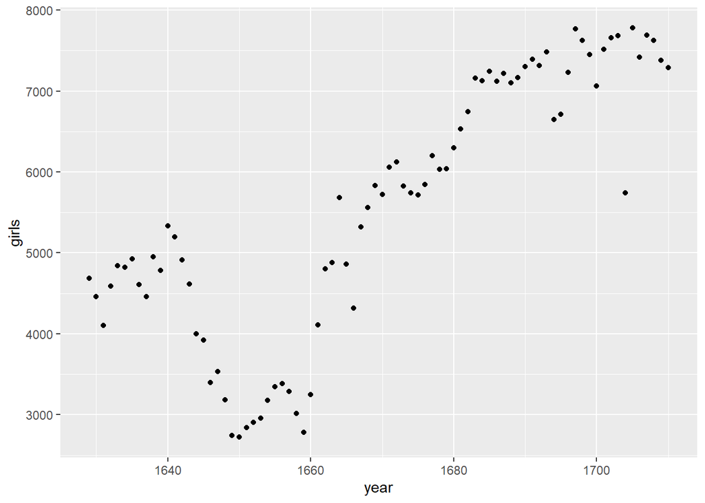

```r
ggplot(data = arbuthnot, aes(x = year, y = girls)) +
  geom_point()
```

Une aide plus complète sur le paquet `ggplot` si besoin : http://docs.ggplot2.org/current/.

Maintenant, supposons que nous voulons tracer le nombre total de baptisés. Si nous ajoutons le vecteur des baptisés pour les garçons à celui des filles, R calculera toutes les sommes simultanément.

```r
arbuthnot$boys + arbuthnot$girls
```

```
##  [1]  9901  9315  8524  9584  9997  9855 10034  9522  9160 10311 10150 10850
## [13] 10670 10370  9410  8104  7966  7163  7332  6544  5825  5612  6071  6128
## [25]  6155  6620  7004  7050  6685  6170  5990  6971  8855 10019 10292 11722
## [37]  9972  8997 10938 11633 12335 11997 12510 12563 11895 11851 11775 12399
## [49] 12626 12601 12288 12847 13355 13653 14735 14702 14730 14694 14951 14588
## [61] 14771 15211 15054 14918 15159 13632 13976 14861 15829 16052 15363 14639
## [73] 15616 15687 15448 11851 16145 15369 16066 15862 15220 14928
```

Nous allons utiliser ce nouveau vecteur pour générer quelques graphiques, nous allons donc vouloir le sauvegarder comme une colonne permanente dans notre `data frame`.

```r
arbuthnot <- arbuthnot %>%
  mutate(total = boys + girls)
```

L’opératuer `%>%` est appelé opérateur de piping. Fondamentalement, il prend la sortie de la ligne actuelle et la met dans la ligne de code suivante. En utilisant la commande `mutate` une nouvelle variable appelée `total` est créée qui est la somme des variables `boys` et `girls` Puis on affecte ce nouveau jeu de données résultant à l’objet appelé `arbuthnot`, c’est à dire on écrase l’ancien jeu de données `arbuthnot` avec le nouveau contenant la nouvelle variable. Vous verrez qu’il y a maintenant une nouvelle colonne appelée `total` qui a été ajoutée au `data frame`. Nous pouvons maintenant tracer le nombre total de baptêmes avec la commande suivante.

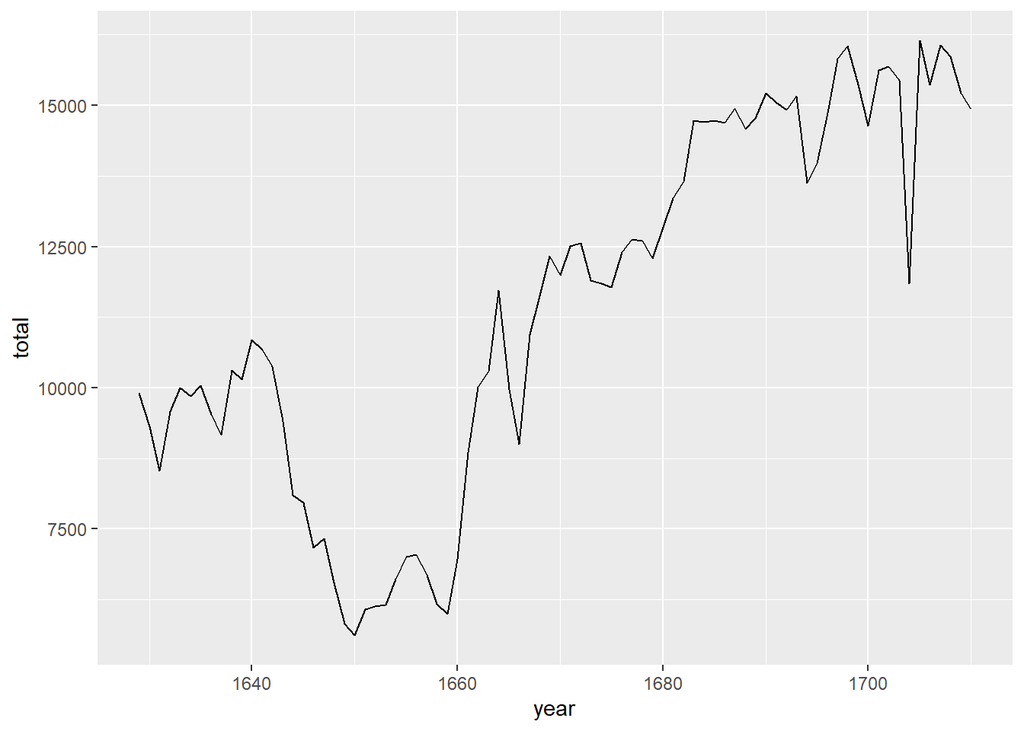

```r
ggplot(data = arbuthnot, aes(x = year, y = total)) +
  geom_line()
```

Noter l’usage de `geom_line()` au lieu de `geom_point()`. Nous pouvons concaténer les deux plots :

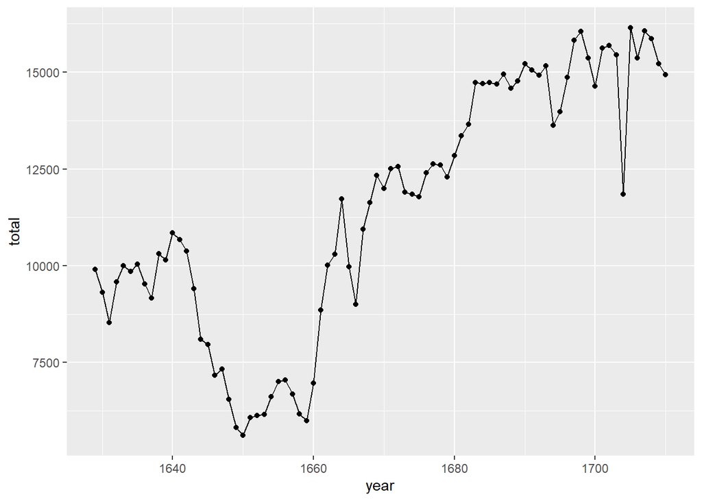

```r
ggplot(data = arbuthnot, aes(x = year, y = total)) +
  geom_line() +
  geom_point()
```

**Exercise**: Maintenant, générer un plot de la proportion de garçons nés à travers le temps. Que voyez-vous?

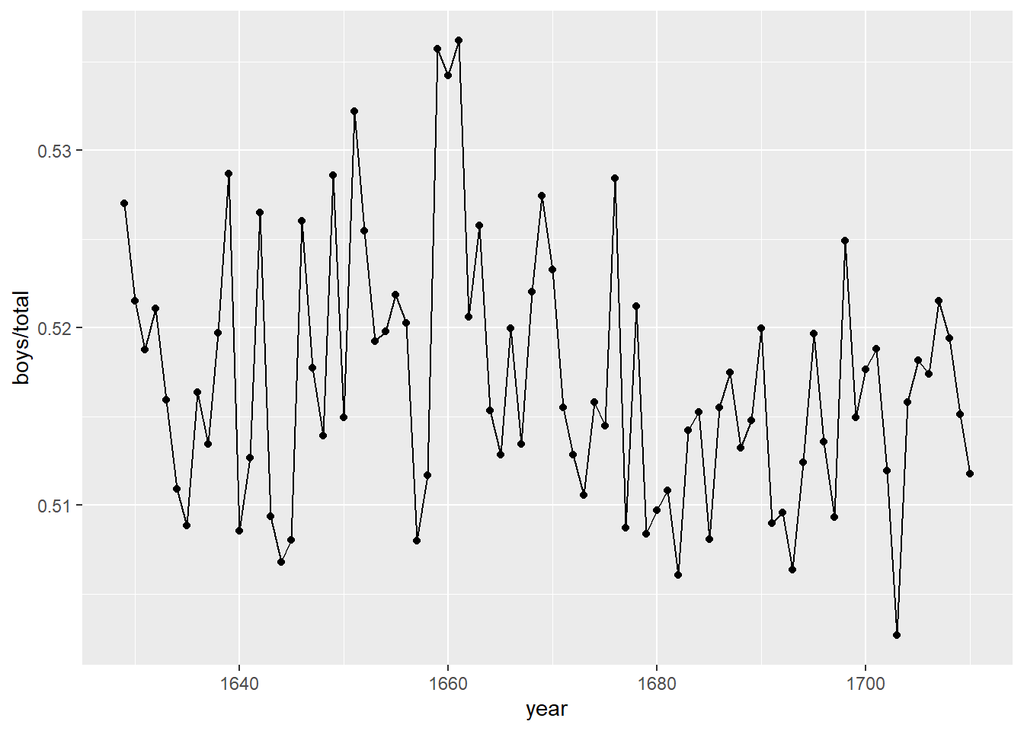

```r
ggplot(data = arbuthnot, aes(x = year, y = boys/total)) +
  geom_line() +
  geom_point()
```

Enfin, nous pouvons faire des opérations mathématiques classiques ou des comparaisons logiques. Par exemple :

```r
arbuthnot <- arbuthnot %>%
  mutate(more_boys = boys > girls)
```

Cette commande ajoute une nouvelle variable au `data frame` contenant les valeurs de `TRUE` si cette année avait plus de garçons que de filles, ou `FALSE` si c’est l’opposé. Cette variable contient des types de données différentes par rapport à celles que nous avons conidérées jusqu’à présent. En général, l’analyse des données impliquera de nombreux types de données, et une raison d’utiliser R est qu’il est capable de représenter et de calculer avec beaucoup d’entre eux.

## Dataset 2: Registre des naissances actuelles

Nous souhaitons faire une analyse similaire pour un jeu de données issu des registres de naissance actuels aux Etats-Unis. Charger les données actuelles avec la commande suivante.

```r
data(present)
```

Les données seront sont stockées dans une `data frame` appelée `present`.

4. Combien de variables sont inclues dans ce jeu de données?
   1. 2
   2. 3
   3. 4
   4. 74
   5. 2013

```r
# Taper votre code ici
dim(present)
```

```
## [1] 74  3
```

**Exercise**: Combien d’années sont inclues dans cette base de données? **Conseil:** Utiliser la fonction `length` puis la fonction `range`.

```r
# Taper votre code ici
present
```

```
## # A tibble: 74 x 3
##     year    boys   girls
##    <dbl>   <dbl>   <dbl>
##  1  1940 1211684 1148715
##  2  1941 1289734 1223693
##  3  1942 1444365 1364631
##  4  1943 1508959 1427901
##  5  1944 1435301 1359499
##  6  1945 1404587 1330869
##  7  1946 1691220 1597452
##  8  1947 1899876 1800064
##  9  1948 1813852 1721216
## 10  1949 1826352 1733177
## # ... with 64 more rows
```

```r
length(present$year)
```

```
## [1] 74
```

5. Calculer le nombre total de naissances pour chaque année et stocker ces valeurs dans une nouvelle variable appelée `total` dans le data frame `present`. Ensuite, calculez la proportion de garçons nés chaque année et stocker ces valeurs dans une nouvelle variable appelée `prop_boys` dans le même jeu de données. Tracer ces valeurs au fil du temps et basé sur ce graphique, déterminer si la déclaration suivante est vraie ou fausse: La proportion de garçons nés aux états-Unis a diminué au fil du temps. Écrire ci-dessous le code R correspondant.
   1. True
   2. False

```r
present <- present %>%
  mutate(total=boys+girls)
```

```r
present <- present %>%
  mutate(prob_boys=boys/total)

present
```

```
## # A tibble: 74 x 5
##     year    boys   girls   total prob_boys
##    <dbl>   <dbl>   <dbl>   <dbl>     <dbl>
##  1  1940 1211684 1148715 2360399     0.513
##  2  1941 1289734 1223693 2513427     0.513
##  3  1942 1444365 1364631 2808996     0.514
##  4  1943 1508959 1427901 2936860     0.514
##  5  1944 1435301 1359499 2794800     0.514
##  6  1945 1404587 1330869 2735456     0.513
##  7  1946 1691220 1597452 3288672     0.514
##  8  1947 1899876 1800064 3699940     0.513
##  9  1948 1813852 1721216 3535068     0.513
## 10  1949 1826352 1733177 3559529     0.513
## # ... with 64 more rows
```

6. Créer une nouvelle variable appelée `more_boys` qui contient la valeur `TRUE` si une année avait plus de garçons que de filles, ou `FALSE` sinon. Basé sur ceci laquelle des affirmations suivantes est vraie?
   1. Chaque année, il y a plus de filles que de garçons.
   2. Chaque année, il y a plus de garçons nés que de filles.
   3. La moitié des années, il y a plus de garçons, et l’autre moitié plus de filles.

```r
present <- present %>%
  mutate(more_boys=prob_boys>0.5)

present
```

```
## # A tibble: 74 x 6
##     year    boys   girls   total prob_boys more_boys
##    <dbl>   <dbl>   <dbl>   <dbl>     <dbl> <lgl>
##  1  1940 1211684 1148715 2360399     0.513 TRUE
##  2  1941 1289734 1223693 2513427     0.513 TRUE
##  3  1942 1444365 1364631 2808996     0.514 TRUE
##  4  1943 1508959 1427901 2936860     0.514 TRUE
##  5  1944 1435301 1359499 2794800     0.514 TRUE
##  6  1945 1404587 1330869 2735456     0.513 TRUE
##  7  1946 1691220 1597452 3288672     0.514 TRUE
##  8  1947 1899876 1800064 3699940     0.513 TRUE
##  9  1948 1813852 1721216 3535068     0.513 TRUE
## 10  1949 1826352 1733177 3559529     0.513 TRUE
## # ... with 64 more rows
```

7. Calculer le rapport garçon-fille chaque année et stockez ces valeurs dans une nouvelle variable appelée `prop_boy_girl` dans l’ensemble de données `present` Tracer ces valeurs au fil du temps. Quelle est la tendance que nous pouvons observer?

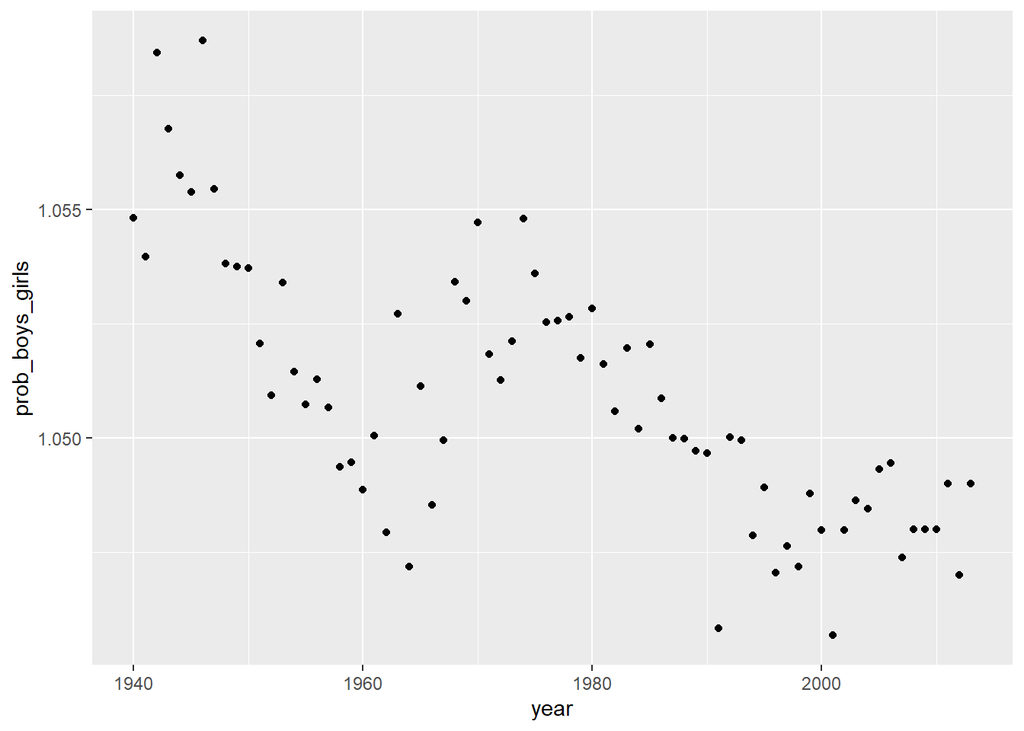

```r
present <- present %>%
  mutate(prob_boys_girls=boys/girls)

ggplot(data = present, aes(x = year, y = prob_boys_girls)) +
  geom_point()
```

8. En quelle année il y a le nombre le plus élevé de naissances aux États-Unis? *Conseil:* Trier votre jeu de données dans l’ordre décroissant basé sur la colonne `total` avec une nouvelle fonction: `desc` (pour descending order).
   1. 1940
   2. 1957
   3. 1961
   4. 1991
   5. 2007

```r
present2 <- present[order(present$total,decreasing =TRUE),]
present2
```

```
## # A tibble: 74 x 7
##     year    boys   girls   total prob_boys more_boys prob_boys_girls
##    <dbl>   <dbl>   <dbl>   <dbl>     <dbl> <lgl>               <dbl>
##  1  2007 2208071 2108162 4316233     0.512 TRUE                 1.05
##  2  1961 2186274 2082052 4268326     0.512 TRUE                 1.05
##  3  2006 2184237 2081318 4265555     0.512 TRUE                 1.05
##  4  1960 2179708 2078142 4257850     0.512 TRUE                 1.05
##  5  1957 2179960 2074824 4254784     0.512 TRUE                 1.05
##  6  2008 2173625 2074069 4247694     0.512 TRUE                 1.05
##  7  1959 2173638 2071158 4244796     0.512 TRUE                 1.05
##  8  1958 2152546 2051266 4203812     0.512 TRUE                 1.05
##  9  1962 2132466 2034896 4167362     0.512 TRUE                 1.05
## 10  1956 2133588 2029502 4163090     0.513 TRUE                 1.05
## # ... with 64 more rows
```